# ESM 204: Homework 2

# Sector D

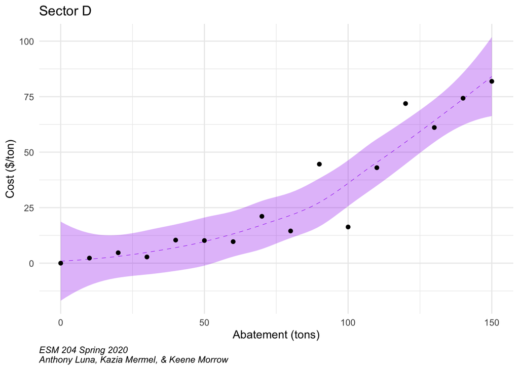

```r
# subset for just Sector C
carbon_d <- carbon_long %>%
  filter(sector == "D")

# Explore data
ggplot(data = carbon_d) +
  geom_smooth(aes(x = abatement,
                  y = mc),
              color = "purple",
              size = 0.2,
              linetype = "dashed",
              fill = "purple",
              alpha = 0.3) +
  geom_point(aes(x = abatement,
                 y = mc)) +
  labs(y = "Cost ($/ton)",
         x = "Abatement (tons)",
         title = "Sector D",
         # subtitle = "",
         caption = "ESM 204 Spring 2020\nAnthony Luna, Kazia Mermel, & Keene Morrow") +
    theme_minimal() +
    theme(plot.caption = element_text(hjust = 0, face = "italic"))
```

```r
# Model Exploration
## Linear
carbon_d_lm <- lm(mc ~ abatement,
                  data = carbon_d)

summary(carbon_d_lm)
```

```
##
## Call:
## lm(formula = mc ~ abatement, data = carbon_d)
##
## Residuals:
##      Min       1Q   Median       3Q      Max
## -26.8368  -5.4924   0.9153   8.9878  17.6938
##
## Coefficients:
##              Estimate Std. Error t value Pr(>|t|)
## (Intercept) -12.21029    5.82038  -2.098   0.0545 .
## abatement     0.55347    0.06612   8.371 8.04e-07 ***
## ---
## Signif. codes:  0 '***' 0.001 '**' 0.01 '*' 0.05 '.' 0.1 ' ' 1
##
## Residual standard error: 12.19 on 14 degrees of freedom
## Multiple R-squared:  0.8335, Adjusted R-squared:  0.8216
## F-statistic: 70.08 on 1 and 14 DF,  p-value: 8.044e-07
```

```r
# Multiple R-squared:  0.8335,  Adjusted R-squared:  0.8216
AIC(carbon_d_lm) # 129.2919
```

```
## [1] 129.2919
```

```r
## Polynomial
### Second Order
carbon_d_lm_poly2 <- lm(mc ~ poly(abatement, 2),
                        data = carbon_d)

summary(carbon_d_lm_poly2)
```

```
##
## Call:
## lm(formula = mc ~ poly(abatement, 2), data = carbon_d)
##
## Residuals:
##      Min       1Q   Median       3Q      Max
## -20.7044  -2.5450  -0.3974   2.4093  18.1026
##
## Coefficients:
##                     Estimate Std. Error t value Pr(>|t|)
## (Intercept)           29.300      2.327   12.59 1.17e-08 ***
## poly(abatement, 2)1  102.055      9.307   10.97 6.11e-08 ***
## poly(abatement, 2)2   30.898      9.307    3.32  0.00553 **
## ---
## Signif. codes:  0 '***' 0.001 '**' 0.01 '*' 0.05 '.' 0.1 ' ' 1
##
## Residual standard error: 9.307 on 13 degrees of freedom
## Multiple R-squared:  0.9099, Adjusted R-squared:  0.896
## F-statistic: 65.63 on 2 and 13 DF,  p-value: 1.607e-07
```

```r
# Multiple R-squared:  0.9099,  Adjusted R-squared:  0.896
AIC(carbon_d_lm_poly2) # 121.4675
```

```
## [1] 121.4675
```

```r
### Third Order
carbon_d_lm_poly3 <- lm(mc ~ poly(abatement, 3),
                        data = carbon_d)

summary(carbon_d_lm_poly3)
```

```
##
## Call:
## lm(formula = mc ~ poly(abatement, 3), data = carbon_d)
##
## Residuals:
##     Min      1Q  Median      3Q     Max
## -20.694  -2.545  -0.401   2.404  18.114
##
## Coefficients:
##                      Estimate Std. Error t value Pr(>|t|)
## (Intercept)          29.30000    2.42169  12.099 4.41e-08 ***
## poly(abatement, 3)1 102.05493    9.68678  10.535 2.03e-07 ***
## poly(abatement, 3)2  30.89797    9.68678   3.190  0.00778 **
## poly(abatement, 3)3   0.04104    9.68678   0.004  0.99669
## ---
## Signif. codes:  0 '***' 0.001 '**' 0.01 '*' 0.05 '.' 0.1 ' ' 1
##
## Residual standard error: 9.687 on 12 degrees of freedom
## Multiple R-squared:  0.9099, Adjusted R-squared:  0.8874
## F-statistic: 40.39 on 3 and 12 DF,  p-value: 1.508e-06
```

```r
# Multiple R-squared:  0.9099,  Adjusted R-squared:  0.8874
AIC(carbon_d_lm_poly3) # 123.4675
```

```
## [1] 123.4675
```

```r
## Non-Linear

# estimate growth rate (r) to be = carbon_d_lm$coefficients[2] ~
# estimate K to be 85
# A = (K - P) / P =

carbon_d_nls <- nls(mc ~ K/(1 + A*exp(-r*abatement)),
                    data = carbon_d,
                    start = list(K = 112,
                                 A = 68,
                                 r = carbon_d_lm$coefficients[2]),
                    trace = TRUE)
```

```
## 104719.3 :  112.0000000  68.0000000   0.5534706
## 34713.5 :  72.6875172 33.5109496  0.4375351
## 24402.26 :  62.901398 16.441036  0.349225
## 14341.86 :  48.381774  3.892253  0.188248
## 7057.979 :  42.18193423  3.45927403  0.04061794
## 6500.02 :  49.73366919  4.10051584  0.01842307
## 6325.437 :  80.08062274  8.18591119  0.01435988
## 2256 :  181.23181004  24.35323464   0.01762191
## 1991.886 :  142.14587184  25.21530048   0.02083088
## 1453.066 :  116.04247978  32.13508173   0.02651795
## 1185.724 :  114.34492479  52.38520082   0.03361214
## 1077.232 :  114.01553247  63.83700085   0.03439163
## 1074.063 :  112.4594252  67.6170634   0.0349616
## 1074.042 :  112.30454573  68.07083017   0.03503108
## 1074.042 :  112.28959295  68.10196402   0.03503728
## 1074.042 :  112.28948555  68.10356911   0.03503749
```

```r
summary(carbon_d_nls) # Residual standard error: 9.089 on 13 degrees of freedom
```

```
##
## Formula: mc ~ K/(1 + A * exp(-r * abatement))
##
## Parameters:
##    Estimate Std. Error t value Pr(>|t|)
## K 112.28949   40.34296   2.783   0.0155 *
## A  68.10357   45.41133   1.500   0.1576
## r   0.03504    0.01091   3.213   0.0068 **
## ---
## Signif. codes:  0 '***' 0.001 '**' 0.01 '*' 0.05 '.' 0.1 ' ' 1
##
## Residual standard error: 9.089 on 13 degrees of freedom
##
## Number of iterations to convergence: 15
## Achieved convergence tolerance: 7.151e-07
```

```r
AIC(carbon_d_nls) # 120.7116
```

```
## [1] 120.7116
```

```r
model_out <- broom::tidy(carbon_d_nls) # cleaner model output with broom
model_out
```

```
## # A tibble: 3 x 5
##   term  estimate std.error statistic p.value
##   <chr>    <dbl>     <dbl>     <dbl>   <dbl>
## 1 K     112.       40.3         2.78 0.0155
## 2 A      68.1      45.4         1.50 0.158
## 3 r       0.0350    0.0109      3.21 0.00680
```

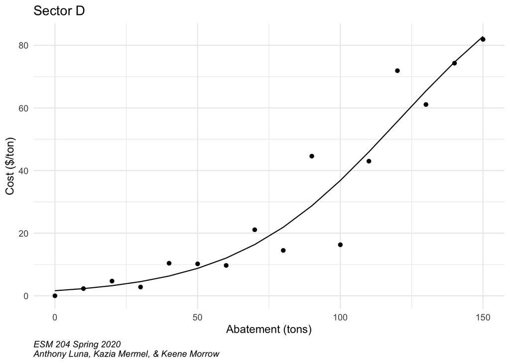

```r
## Predicted values using the nls model for plotting
predict_carbon_d_nls <- data.frame(mc_predict = predict(carbon_d_nls, carbon_d$abatement),
                                   sector = "D",
                                   abatement = carbon_d$abatement)

ggplot()+
  # geom_smooth(data = carbon_d,
  #             aes(x = abatement,
  #                 y = mc),
  #             color = "purple",
  #             size = 0.2,
  #             linetype = "dashed",
  #             fill = "purple",
  #             alpha = 0.3) +
  geom_point(data = carbon_d,
             aes(x = abatement,
                 y = mc)) +
  geom_path(data = predict_carbon_d_nls,
            aes(x = abatement,
                y = mc_predict)) +
  labs(y = "Cost ($/ton)",
         x = "Abatement (tons)",
         title = "Sector D",
         # subtitle = "",
         caption = "ESM 204 Spring 2020\nAnthony Luna, Kazia Mermel, & Keene Morrow") +
    theme_minimal() +
    theme(plot.caption = element_text(hjust = 0, face = "italic"))
```

2. Using these models (i.e. use the functions you have estimated, not the data themselves) and the current level of carbon emissions (provided above), derive each sector’s demand curve for carbon emissions. In other words, how much would each sector be willing to pay for the right to pollute the first ton, second ton, etc.? Plot each sector’s demand curve for carbon emissions on a graph.
3. Now focus on country X (which contains sectors A, B, and C). Assume there are no “co-benefits” from carbon abatement (i.e. that there are no local pollutants that are affected by carbon abatement). Suppose to meet the Paris Accord commitments, country X needs to cut all carbon emissions in half. For each of the policy options listed below, derive: (1) the total cost of meeting the target in country X, (2) the cost (or benefit) to each sector, and (3) the tax revenue generated.
1. Cap on carbon. Each sector (A, B, and C) must cut its carbon emissions by 100 tons (thus reducing total emissions from 600 down to 300).
2. Tax on carbon. To emit a ton of carbon in country X, you must pay a tax of $t. You will need to find the tax that accomplishes the desired reduction.

*Notes from Section* **Aggregate (Qa+Qb+Qc) must equal emissions goal. Find tax based off that value** **Linear model is okay as long as you say it’s not the least R^2 value. Sam may give bonus points for non-linear**

3. Cap and trade. Each sector (A, B, C) is allocated carbon permits equal to their current emissions minus 100 (same as in (a) above), thus achieving the total reduction of 300. Then, these three sectors are allowed to trade with each other. You will need to derive the outcome of that trading.
4. Again, without any co-benefits, suppose that country Y (which only has one carbon-emitting sector, D) has no obligation to reduce its emissions. Country X asks country Y to enter the country X carbon market. Doing so would require country Y to put a cap on carbon emissions at its current level of emissions (300 tons), but would then allow country Y to sell carbon offsets to sectors A, B, and/or C. Are there any incentives for country Y to enter country X’s carbon market and to thus place a voluntary cap on its emissions? Are there any incentives for country X to try to attract country Y into its market? Describe these incentives as quantitatively as possible.